# Activity Monitoring Data Analysis

Xiang Li

May 17, 2017

## Loading and preprocessing the data

```r
activity = read.csv("Q:/Desktop/Coursera/5. Reproducible Research/activity.csv")
```

```r
# Explore the dataset
head(activity)
```

```
##   steps       date interval
## 1    NA 2012-10-01        0
## 2    NA 2012-10-01        5
## 3    NA 2012-10-01       10
## 4    NA 2012-10-01       15
## 5    NA 2012-10-01       20
## 6    NA 2012-10-01       25
```

```r
summary(activity)
```

```
##      steps                date          interval
##  Min.   :  0.00   2012-10-01:  288   Min.   :   0.0
##  1st Qu.:  0.00   2012-10-02:  288   1st Qu.: 588.8
##  Median :  0.00   2012-10-03:  288   Median :1177.5
##  Mean   : 37.38   2012-10-04:  288   Mean   :1177.5
##  3rd Qu.: 12.00   2012-10-05:  288   3rd Qu.:1766.2
##  Max.   :806.00   2012-10-06:  288   Max.   :2355.0
##  NA's   :2304     (Other)   :15840
```

```r
str(activity)
```

```
## 'data.frame':    17568 obs. of  3 variables:
##  $ steps   : int  NA NA NA NA NA NA NA NA NA NA ...
##  $ date    : Factor w/ 61 levels "2012-10-01","2012-10-02",..: 1 1 1 1 1 1 1 1 1 1 ...
##  $ interval: int  0 5 10 15 20 25 30 35 40 45 ...
```

## What is mean total number of steps taken per day?

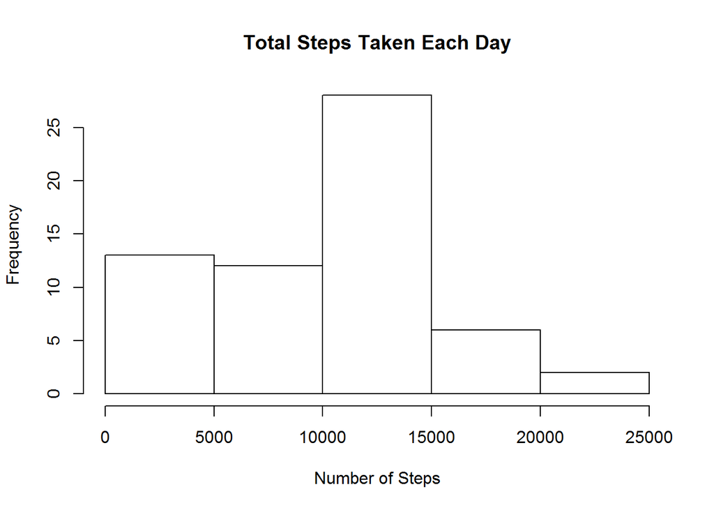

```r
# Calculate the steps by date
library(data.table)
activity = data.table(activity)
totalsteps = activity[, list(total_steps = sum(steps, na.rm = TRUE)), by = date]

# Plot the histogram
hist(totalsteps$total_steps, main = "Total Steps Taken Each Day", xlab = "Number of Steps")
```

```r
# calculate the mean number of steps taken each day
mean_step = round(mean(totalsteps$total_steps, na.rm = TRUE),0)
mean_step
```

```
## [1] 9354
```

```r
# calculate the median number of steps taken each day
median_step = round(median(totalsteps$total_steps, na.rm = TRUE),0)
median_step
```

```
## [1] 10395
```

The mean of steps taken each day is 9354 steps and the median is 10395 steps.

## What is the average daily activity pattern?

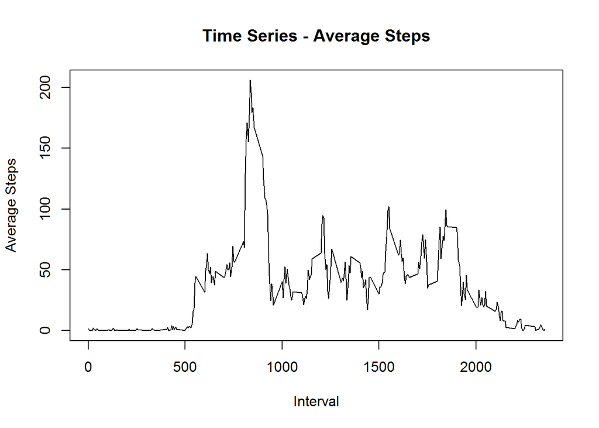

```r
# Calculate the average steps by interval
library(data.table)
activity = data.table(activity)
avgsteps = activity[, list(avg_steps = mean(steps, na.rm = TRUE)), by = interval]

# Plot the time series chart
with(avgsteps, plot(interval, avg_steps, type = "l", main = "Time Series - Average Steps",
                    xlab = "Interval", ylab = "Average Steps"))
```

```r
#The interval that contains the maximum number of steps
avgsteps[which.max(avgsteps$avg_steps),]$interval
```

```
## [1] 835
```

## Imputing missing values

```r
# Look at missing data pattern
library(mice)
md.pattern(activity)
```

```
##       date interval steps
## 15264    1        1     1    0
##  2304    1        1     0    1
##          0        0  2304 2304
```

The output tells us that 15264 samples are complete, 2304 samples miss only the steps value.

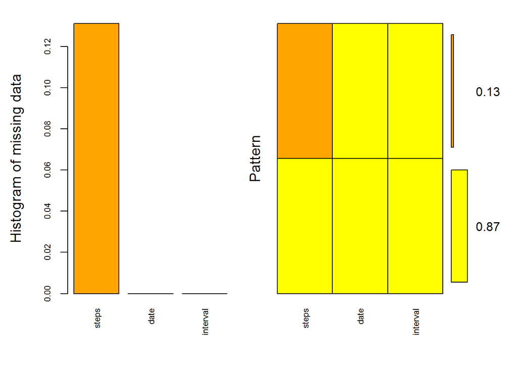

```r
# Visualize missing data pattern
library(VIM)
aggr_plot = aggr(activity, col = c('yellow', 'orange'),
                 numbers = TRUE, sortVars = TRUE, labels = names(activity),
                 cex.axis = 0.7, gap = 3, ylab = c("Histogram of missing data", "Pattern"))
```

The plot helps us understanding that 87% of the samples are not missing any information, 13% are missing the Steps value.

```r
# Impute the missing data
tempData = mice(activity, m = 5, maxit = 50, meth = "pmm", seed = 500)
```

```r
summary(tempData)
```

```
## Multiply imputed data set
## Call:
## mice(data = activity, m = 5, method = "pmm", maxit = 50, seed = 500)
## Number of multiple imputations:  5
## Missing cells per column:
##    steps     date interval
##     2304        0        0
## Imputation methods:
##    steps     date interval
##    "pmm"    "pmm"    "pmm"
## VisitSequence:
## steps
##     1
## PredictorMatrix:
##          steps date interval
## steps        0    1        1
## date         0    0        0
## interval     0    0        0
## Random generator seed value:  500
```

```r
# Check the imputed data
head(tempData$imp$steps, 10)
```

```
##    1   2  3   4   5
## 1  0  33  0  84 179
## 2  0   0 25   0   0
## 3  0   0  0   0   0
## 4  0  19  0   0   0
## 5  0   0 23 189   0
## 6  0  73 23   0   0
## 7  0   0  0   0 111
## 8  0   0  0   0   0
## 9  0 415  0   0   0
## 10 0 356  0   0   0
```

The output shows the imputed data for each observation (first column left) within each imputed dataset (first row at the top).

```r
# Get back the completed dataset
Imputed_activity = complete(tempData, 1)
```

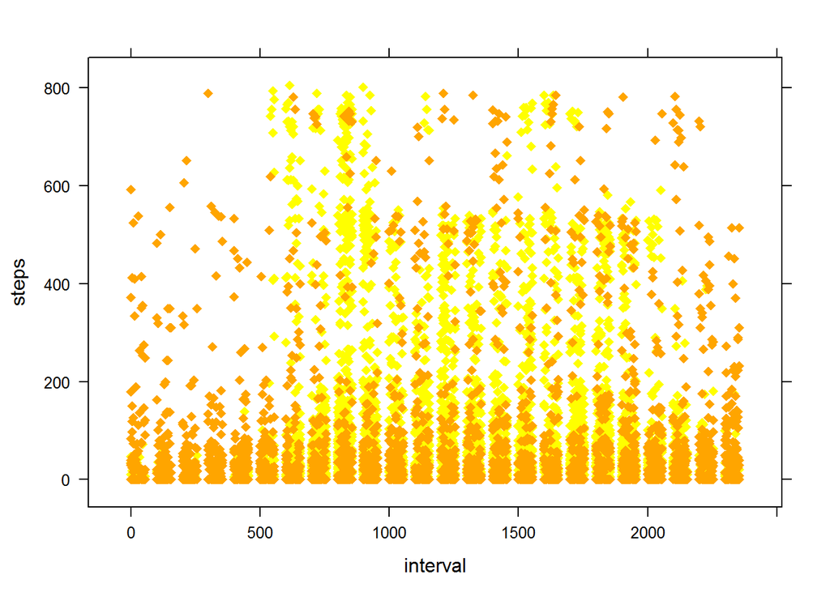

```r
# Inspect the distribution of original and imputed data
library(lattice)
# Scatterplot to plot steps against interval
xyplot(tempData,steps ~ interval, pch = 18, cex = 1, col = c('yellow', 'orange'))
```

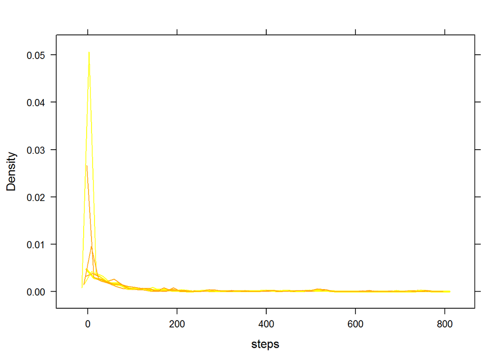

```r
# Density plot
densityplot(tempData, col = c('yellow', 'orange'))
```

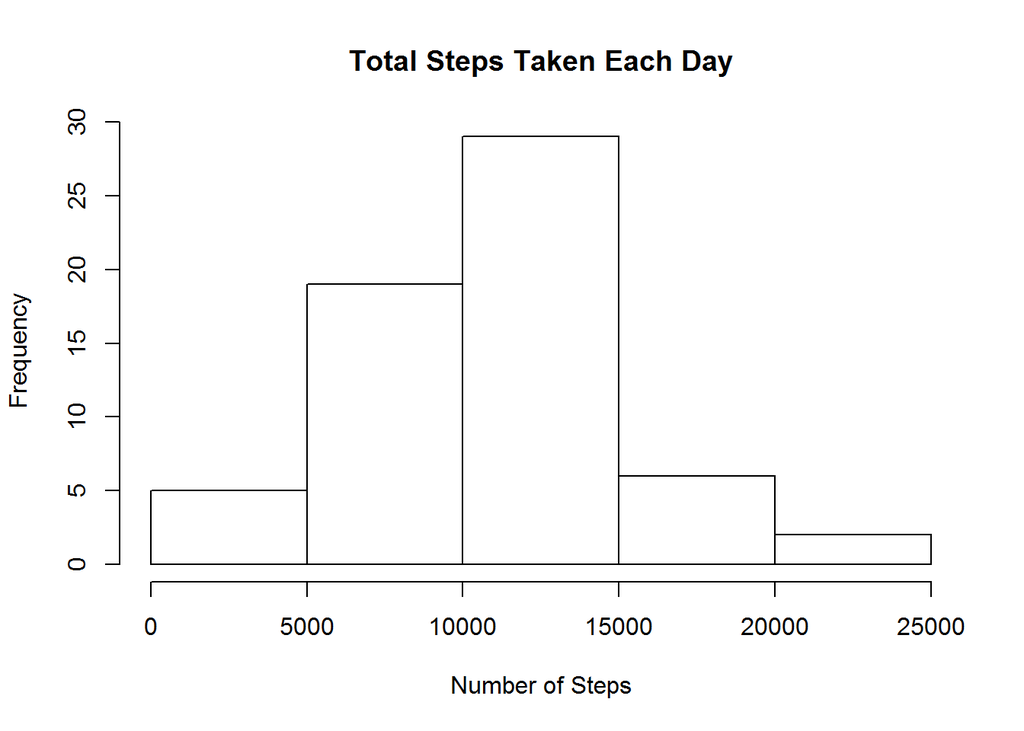

```r
# Histogram of the total number of steps taken each day after missing values are imputed
# Calculate the steps by date
library(data.table)
Imputed_activity = data.table(Imputed_activity)
totalsteps1 = Imputed_activity[, list(total_steps = sum(steps)), by = date]

# Plot the histogram
hist(totalsteps1$total_steps, main = "Total Steps Taken Each Day", xlab = "Number of Steps")
```

```r
# Calculate the mean number of steps taken each day
mean_step = round(mean(totalsteps1$total_steps),0)
mean_step
```

```
## [1] 10400
```

```r
# calculate the median number of steps taken each day
median_step = round(median(totalsteps1$total_steps),0)
median_step
```

```
## [1] 10439
```

Before Imputing: The mean of steps taken each day is 9354 steps and the median is 10395 steps. After Imputing: The mean of steps taken each day is 10400 steps and the median is 10439 steps. Conclusion: Imputing missing data increase the mean and median of the total daily number of steps.

## Are there differences in activity patterns between weekdays and weekends?

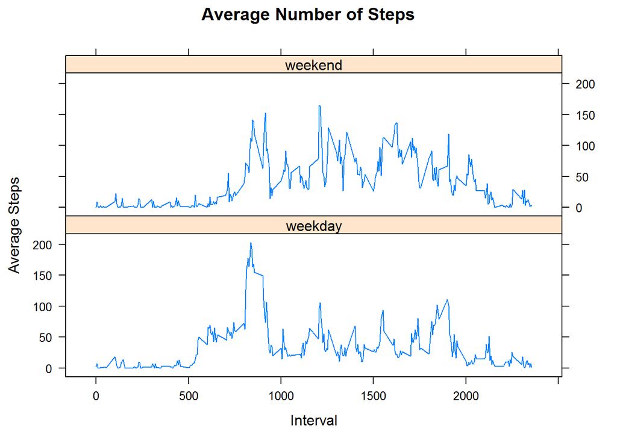

```r
# Add a column identifying weekdays and weekends
Imputed_activity$Day <- ifelse(weekdays(as.Date(Imputed_activity$date)) %in% c("Saturday", "Sunday"), "weekend", "weekday")

# Calculate the average steps by interval
library(plyr)
avgsteps = ddply(Imputed_activity, .(interval, Day), summarize, avg_steps = mean(steps))

# Plot the time series charts
library(lattice)
xyplot(avgsteps$avg_steps ~ avgsteps$interval | factor(avgsteps$Day), type = 'l', layout = c(1,2), main = "Average Number of Steps", xlab = "Interval", ylab = "Average Steps")
```

Conclusion: There are differences in activity patterns between weekdays and weekends. On average this person exercise more on weekend, which makes sense because he/she might have more free time to workout on weekends than on weekdays.